# Analyze_ab_test_results_Mai_Nguyen

## Analyze A/B Test Results

### by Mai Nguyen

- Introduction
- Part I - Probability
- Part II - A/B Test
- Part III - Regression

### Introduction

For this project, I will be working to understand the results of an A/B test run by an e-commerce website. My goal is to help the company understand if they should implement the new page, keep the old page, or perhaps run the experiment longer to make their decision.

#### Part I - Probability

To get started, let's import the libraries.

```python
import pandas as pd
import numpy as np
import random
import matplotlib.pyplot as plt
%matplotlib inline

random.seed(42)
```

`1.` Now, read in the `ab_data.csv` data. Store it in `df`.

a. Read in the dataset and take a look at the top few rows:

```python
df = pd.read_csv('ab_data.csv')
df.head()
```

|  | user_id | timestamp | group | landing_page | converted |
| --- | --- | --- | --- | --- | --- |
| 0 | 851104 | 2017-01-21 22:11:48.556739 | control | old_page | 0 |
| 1 | 804228 | 2017-01-12 08:01:45.159739 | control | old_page | 0 |
| 2 | 661590 | 2017-01-11 16:55:06.154213 | treatment | new_page | 0 |
| 3 | 853541 | 2017-01-08 18:28:03.143765 | treatment | new_page | 0 |
| 4 | 864975 | 2017-01-21 01:52:26.210827 | control | old_page | 1 |

b. The number of rows in the dataset is:

```python
df.shape[0]
```

```
294478
```

c. The number of unique users in the dataset is:

```python
df['user_id'].nunique()
```

```
290584
```

d. The proportion of users converted:

```python
df['converted'].mean()
```

```
0.11965919355605512
```

e. The number of times the `new_page` and `treatment` don't line up:

```python
df[(df['landing_page'] == 'new_page') == (df['group'] == 'control')].count()
```

```
user_id         3893
timestamp       3893
group           3893
landing_page    3893
converted       3893
dtype: int64
```

f. See if any rows have missing values. No missing values are found in the data.

```python
df.info()
```

```
<class 'pandas.core.frame.DataFrame'>
RangeIndex: 294478 entries, 0 to 294477
Data columns (total 5 columns):
user_id         294478 non-null int64
timestamp       294478 non-null object
group           294478 non-null object
landing_page    294478 non-null object
converted       294478 non-null int64
dtypes: int64(2), object(3)
memory usage: 11.2+ MB
```

`2.` For the rows where **treatment** is not aligned with **new_page** or **control** is not aligned with **old_page**, we cannot be sure if this row truly received the new or old page.

a. Therefore, now I create a new dataset that meets the specifications that new_page is aligned with treatment group, and old_page is for the control group.. Store the new dataframe in **df2**.

```python
df2 = df[(df['landing_page'] == 'new_page') == (df['group'] == 'treatment')]
```

```python
# Double Check all of these rows were removed - this should be 0
df2[((df2['group'] == 'treatment') == (df2['landing_page'] == 'new_page')) == False].shape[0]
```

```
0
```

```python
df2.head()
```

|  | user_id | timestamp | group | landing_page | converted |
| --- | --- | --- | --- | --- | --- |
| 0 | 851104 | 2017-01-21 22:11:48.556739 | control | old_page | 0 |
| 1 | 804228 | 2017-01-12 08:01:45.159739 | control | old_page | 0 |
| 2 | 661590 | 2017-01-11 16:55:06.154213 | treatment | new_page | 0 |
| 3 | 853541 | 2017-01-08 18:28:03.143765 | treatment | new_page | 0 |
| 4 | 864975 | 2017-01-21 01:52:26.210827 | control | old_page | 1 |

`3.` Clean df2 dataset

a. The number of unique **user_id**s are in **df2** is

```python
df2['user_id'].nunique()
```

```
290584
```

b. There is one **user_id** repeated in **df2**:

```python
df2[df2['user_id'].duplicated() == True]['user_id']
```

```
2893    773192
Name: user_id, dtype: int64
```

c. The row information for the repeat **user_id**:

```python
df2[df2['user_id'].duplicated() == True]
```

|  | user_id | timestamp | group | landing_page | converted |
| --- | --- | --- | --- | --- | --- |
| 2893 | 773192 | 2017-01-14 02:55:59.590927 | treatment | new_page | 0 |

d. Remove **one** of the rows with a duplicate **user_id**, but keep our dataframe as **df2**.

```python
df2 = df2.drop_duplicates(subset = 'user_id')
```

`4.` Overview on probability:

a. The probability of an individual converting regardless of the page they receive is:

```python
df2['converted'].mean()
```

```
0.11959708724499628
```

b. Given that an individual was in the `control` group, the probability they converted is:

```python
df2.query('group == "control"').converted.mean()
```

```
0.1203863045004612
```

c. Given that an individual was in the `treatment` group, the probability they converted is:

```python
df2.query('group == "treatment"').converted.mean()
```

```
0.11880806551510564
```

d.The probability that an individual received the new page is:

```python
df.query('landing_page == "new_page"')['user_id'].count()/df['user_id'].count()
```

```
0.5
```

e. Consider the results from a. through d. above, my observation on whether there is sufficient evidence to say that the new treatment page leads to more conversions is:

> **The design of the test is good since the probability an individual received the new page and the old page is the same. In this sample, the conversion rate in the treatment group is lower than the control group. We have to investigate if this difference is significant, and not just due to chance.**

### Part II - A/B Test

Notice that because of the time stamp associated with each event, we could technically run a hypothesis test continuously as each observation was observed.

However, then the hard question is should we stop as soon as one page is considered significantly better than another or does it need to happen consistently for a certain amount of time? How long do we run to render a decision that neither page is better than another?

These questions are the difficult parts associated with A/B tests in general.

`1.` For now, consider we need to make the decision just based on all the data provided. If wewant to assume that the old page is better unless the new page proves to be definitely better at a Type I error rate of 5%, the null and alternative hypothesses should be:

$$ \begin{array}{c} H_0: p_{new} - p_{old} <= 0 \cr H_1: p_{new} - p_{old} > 0 \cr \end{array} $$

`2.` Assume under the null hypothesis, $p_{new}$ and $p_{old}$ both have "true" success rates equal to the **converted** success rate regardless of page - that is $p_{new}$ and $p_{old}$ are equal. Furthermore, assume they are equal to the **converted** rate in **ab_data.csv** regardless of the page.

Now, I use a sample size for each page equal to the ones in **ab_data.csv**.

I perform the sampling distribution for the difference in **converted** between the two pages over 10,000 iterations of calculating an estimate from the null.

a. The **convert rate** for $p_{new}$ under the null?

```python
df2['converted'].mean()
```

```
0.11959708724499628
```

b. The **convert rate** for $p_{old}$ under the null?

```python
df2['converted'].mean()
```

```
0.11959708724499628
```

> Now we will create seperate dataframes for the treatment group and the control group, and find the observed statistic in this sample:

```python
# Creat dataframe of the treatment group:
treatment_df = df2.query('group == "treatment"')
```

```python
# Creat dataframe of the control group:
control_df = df2.query('group == "control"')
```

```python
# Find the observed statistic, which is the difference in conversion rate between the new rate and the old rate,  in the sample:
obs_diff = treatment_df['converted'].mean() - control_df['converted'].mean()
obs_diff
```

```
-0.0015782389853555567
```

c. $n_{new}$ is:

```python
n_new = treatment_df['user_id'].count()
n_new
```

```
145310
```

d. $n_{old}$ is:

```python
n_old = control_df['user_id'].count()
n_old
```

```
145274
```

e. Simulate $n_{new}$ transactions with a convert rate of $p_{new}$ under the null. Store these $n_{new}$ 1's and 0's in **new_page_converted**.

```python
new_page_converted = treatment_df['converted'].sample(n_new, replace = True)
```

f. Simulate $n_{old}$ transactions with a convert rate of $p_{old}$ under the null. Store these $n_{old}$ 1's and 0's in **old_page_converted**.

```python
old_page_converted = control_df['converted'].sample(n_old, replace = True)
```

g. Find $p_{new}$ - $p_{old}$ for the simulated values from part (e) and (f).

```python
new_page_converted.mean() - old_page_converted.mean()
```

```
-0.002087877061884527
```

h. Simulate 10,000 $p_{new}$ - $p_{old}$ values using this same process similarly to the one I calculated in parts **a. through g.** above. Store all 10,000 values in a numpy array called **p_diffs**.

```python
# Stimulate the sampling distribution for the difference between conversion rates of the new and old page.
p_diffs_sample_dist = []
for _ in range (10000):
    new_samp = treatment_df['converted'].sample(n_new, replace = True)
    old_samp = control_df['converted'].sample(n_old, replace = True)
    p_diffs_sample_dist.append(new_samp.mean() - old_samp.mean())
```

```python
# Use the sampling distribution above to stimulate the distribution under the null hypothesis, by creating
# a random normal distribution centered at 0 with the same spread and size

p_diffs_sample_dist = np.asarray(p_diffs_sample_dist)
p_diffs = np.random.normal(0, p_diffs_sample_dist.std(), p_diffs_sample_dist.size)
```

i. Plot a histogram of the **p_diffs**.

```python
p_diffs = np.asarray(p_diffs)
```

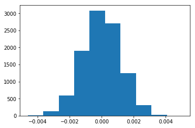

```python
plt.hist(p_diffs)
plt.show()
```

> The plot look like expected, which is the shape of a normal distribution with center at 0.

j. What proportion of the **p_diffs** are greater than the actual difference observed in **ab_data.csv**?

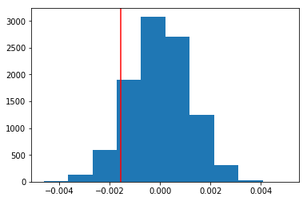

```python
plt.hist(p_diffs)
plt.axvline(obs_diff, color = "red")
plt.show()
```

```python
# proportion of the p_diffs are greater than the actual difference observed in ab_data.csv:
print("p-value is :")
print((p_diffs > obs_diff).mean())
```

```
p-value is :
0.9066
```

k. p-value analysis:

> **The proportion of values in the null distribution that is greater than the observed difference is the p-value, which the probability of observing our statistic (or one more extreme) in favor of the alternative if the null hypothesis is true. It is used to determine the statistical significance of the observed difference. The p-value here is greater than 0.05 (the Type 1 error rate), indicating that we fail to reject the null hypothesis, or the difference between the new and old page is not statistically significant. It means that the new page is equal to or worse than the old page in terms of conversion rate.**

l. **Alternatively, we can conduct z-test to determine p-value by built-in functions:**

We could also use a built-in to achieve similar results. Though using the built-in might be easier to code, the above portions are a walkthrough of the ideas that are critical to correctly thinking about statistical significance. Let `n_old` and `n_new` refer the the number of rows associated with the old page and new pages, respectively.

```python
import statsmodels.api as sm

convert_old = treatment_df['converted'].sum()
convert_new = control_df['converted'].sum()
print("n-old is", n_old)
print("n-new is", n_new)
```

```
n-old is 145274
n-new is 145310
```

m. Now use `stats.proportions_ztest` to compute the test statistic and p-value.

```python
z_score, p_value = sm.stats.proportions_ztest([convert_old, convert_new], [n_old, n_new], alternative ='larger')
print("z-score", z_score)
print("p_value", p_value)
```

```
z-score -1.2616957421858055
p_value 0.8964708551967226
```

```python
from scipy.stats import norm
# Tells the critical value at α = 0.05 for one-tailed z-test:
norm.ppf(1-0.05)
```

```
1.6448536269514722
```

> For further insight, we examine how long this AB test is performed.

```python
#Duration of AB test
sort_time = pd.to_datetime(df['timestamp'], format="%Y-%m-%d %H:%M:%S.%f").sort_values()
duration = sort_time[193652] - sort_time[131228]
duration
```

```
Timedelta('21 days 23:59:49.081927')
```

### Part III - A regression approach

`1.` In this final part, I will see that the result achieved in the previous A/B test can also be acheived by performing regression.

a. Since each row is either a conversion or no conversion, I will perform logistic regression.

b. The goal is to use **statsmodels** to fit the regression model I specified in part **a.** to see if there is a significant difference in conversion based on which page a customer receives. However, I first need to create a column for the intercept, and create a dummy variable column for which page each user received. Add an **intercept** column, as well as an **ab_page** column, which is 1 when an individual receives the **treatment** and 0 if **control**.

```python
# Create dummy variable column for which page each user received:
df2[['control', 'ab_page']] = pd.get_dummies(df2['group'])
df2.drop('control', axis = 1, inplace = True)
```

```python
# Creat a column for the intercept
df2['intercept'] = 1
```

c. Use **statsmodels** to import the regression model. Instantiate the model, and fit the model using the two columns I created in part **b.** to predict whether or not an individual converts.

```python
model = sm.Logit(df2['converted'], df2[['intercept', 'ab_page']])
results = model.fit()
```

```
Optimization terminated successfully.
         Current function value: 0.366118
         Iterations 6
```

d. The summary of the model is:

```python
results.summary2()
```

| Model: | Logit | No. Iterations: | 6.0000 |
| --- | --- | --- | --- |
| Dependent Variable: | converted | Pseudo R-squared: | 0.000 |
| Date: | 2018-06-08 11:28 | AIC: | 212780.3502 |
| No. Observations: | 290584 | BIC: | 212801.5095 |
| Df Model: | 1 | Log-Likelihood: | -1.0639e+05 |
| Df Residuals: | 290582 | LL-Null: | -1.0639e+05 |
| Converged: | 1.0000 | Scale: | 1.0000 |

|  | Coef. | Std.Err. | z | P>\|z\| | [0.025 | 0.975] |
| --- | --- | --- | --- | --- | --- | --- |
| intercept | -1.9888 | 0.0081 | -246.6690 | 0.0000 | -2.0046 | -1.9730 |
| ab_page | -0.0150 | 0.0114 | -1.3109 | 0.1899 | -0.0374 | 0.0074 |

e. p-value analysis:

> *The p-value associated with ab_page is is 0.190. It is different from the value found in Part II. The reason for this difference is that:*
> - In the regression model, the null hypothesis is that the coefficient on ab_page is equal to 0, and the alternative hypothsis is that such coefficient is different from 0. In this model, p-value > 0.05, which is the Type 1 error rate, indicating that we fail to reject the null hypothesis that the coefficient on ab_page is equal to 0. The effect of ab_page on conversion rate is statistically insignificant.
> - Meanwhile, in part II, the null hypothesis is that the conversion rate of the new page is equal or worse than the old page, and the alternative hypothesis is that the new page is better than the old page in terms of conversion rate.

f. Now, I am considering other things that might influence whether or not an individual converts.

> *There can be other factors that may have an influence whether or not an individual converts, such as personal characteristics of the individual, including gender, age, education background, living location, etc., or factors such as time of the day, week, season.*
> - Adding other factors can increase the R-square, or the variability of the independent variable explained by the model, which represents explanatory power of the model. Besides, omitting relevant variables that are correlated with included variables can bias regression estimates.
> - There are some disadvantages of adding additional terms into the regression model. First, inclusion of irrelevant variables reduces model parsimony, which may be critical in the interpretation of the results. Second, adding more independent variables require larger sample size to increase the degree of freedom as a measure of the generalizability of the results. Therefore, research design of the regression model is important.

g. Now along with testing if the conversion rate changes for different pages, also add an effect based on which country a user lives. I will read in the **countries.csv** dataset and merge together the datasets on the approporiate rows. [Here](https://pandas.pydata.org/pandas-docs/stable/generated/pandas.DataFrame.join.html) are the docs for joining tables.

The question is whether the country had an impact on conversion?

```python
countries_df = pd.read_csv('./countries.csv')
df_new = countries_df.set_index('user_id').join(df2.set_index('user_id'), how='inner')
```

```python
# Show unique values in the country column
df_new['country'].unique()
```

```
array(['UK', 'US', 'CA'], dtype=object)
```

```python
### Create the necessary dummy variables
df_new[['CA', 'UK', 'US']] = pd.get_dummies(df_new['country'])
df_new.drop('CA', axis = 1, inplace = True)
```

```python
# logistic regression model with the added effect baed on which country a user lives
model2 = sm.Logit(df_new['converted'], df_new[['intercept', 'ab_page', 'UK', 'US']])
results = model2.fit()
results.summary2()
```

```
Optimization terminated successfully.
         Current function value: 0.366113
         Iterations 6
```

| Model: | Logit | No. Iterations: | 6.0000 |
| --- | --- | --- | --- |
| Dependent Variable: | converted | Pseudo R-squared: | 0.000 |
| Date: | 2018-06-08 11:30 | AIC: | 212781.1253 |
| No. Observations: | 290584 | BIC: | 212823.4439 |
| Df Model: | 3 | Log-Likelihood: | -1.0639e+05 |
| Df Residuals: | 290580 | LL-Null: | -1.0639e+05 |
| Converged: | 1.0000 | Scale: | 1.0000 |

|  | Coef. | Std.Err. | z | P>\|z\| | [0.025 | 0.975] |
| --- | --- | --- | --- | --- | --- | --- |
| intercept | -2.0300 | 0.0266 | -76.2488 | 0.0000 | -2.0822 | -1.9778 |
| ab_page | -0.0149 | 0.0114 | -1.3069 | 0.1912 | -0.0374 | 0.0075 |
| UK | 0.0506 | 0.0284 | 1.7835 | 0.0745 | -0.0050 | 0.1063 |
| US | 0.0408 | 0.0269 | 1.5161 | 0.1295 | -0.0119 | 0.0934 |

- From the above results, we see that the p-values associated with the coefficients on the dummy variables representing where a user lives are all greater than 0.05. They indicate that the effect of the country where a user lives on the conversion rate is not statiscally significant.

h. Though I have now looked at the individual factors of country and page on conversion, I would now like to look at an interaction between page and country to see if there significant effects on conversion. Create the necessary additional columns, and fit the new model.

```python
# Create the column for the interaction term between ab_page and UK dummy variable:
df_new['ab_page_UK'] = df_new['ab_page']*df_new['UK']
```

```python
# Create the column for the interaction term between ab_page and US dummy variable:
df_new['ab_page_US'] = df_new['ab_page']*df_new['US']
```

```python
### Fit The Linear Model And Obtain the Results
model3 = sm.Logit(df_new['converted'], df_new[['intercept', 'ab_page', 'UK', 'US', 'ab_page_UK', 'ab_page_US']])
results = model3.fit()
results.summary2()
```

```
Optimization terminated successfully.
         Current function value: 0.366109
         Iterations 6
```

| Model: | Logit | No. Iterations: | 6.0000 |
| --- | --- | --- | --- |
| Dependent Variable: | converted | Pseudo R-squared: | 0.000 |
| Date: | 2018-06-08 11:31 | AIC: | 212782.6602 |
| No. Observations: | 290584 | BIC: | 212846.1381 |
| Df Model: | 5 | Log-Likelihood: | -1.0639e+05 |
| Df Residuals: | 290578 | LL-Null: | -1.0639e+05 |
| Converged: | 1.0000 | Scale: | 1.0000 |

|  | Coef. | Std.Err. | z | P>\|z\| | [0.025 | 0.975] |
| --- | --- | --- | --- | --- | --- | --- |
| intercept | -2.0040 | 0.0364 | -55.0077 | 0.0000 | -2.0754 | -1.9326 |
| ab_page | -0.0674 | 0.0520 | -1.2967 | 0.1947 | -0.1694 | 0.0345 |
| UK | 0.0118 | 0.0398 | 0.2957 | 0.7674 | -0.0663 | 0.0899 |
| US | 0.0175 | 0.0377 | 0.4652 | 0.6418 | -0.0563 | 0.0914 |
| ab_page_UK | 0.0783 | 0.0568 | 1.3783 | 0.1681 | -0.0330 | 0.1896 |
| ab_page_US | 0.0469 | 0.0538 | 0.8718 | 0.3833 | -0.0585 | 0.1523 |

- We see that the p-values associated with both interaction terms are higher than 0.05, indicating that the moderating effect of where a user lives on the relationship between ab_page and convertion rate is not statistically significant.